# Lecture #16: Trigonometric Functions and their Derivatives

MATH 145 – Calculus I

Torin Quinlivan

tquinlivan@knox.edu

Knox College

October 26, 2025

## Radians

Generally, in real life, and in your high school geometry classes, you might have used degrees to measure the size of angles. In calculus, we tend to use the radian instead.

The radian measure of the size of an angle is the length of the arc of a circle of radius $r = 1$ swept out by the angle, with positive values corresponding to counterclockwise rotation and negative values corresponding to clockwise rotation.

The circumference of the full unit circle is $C = 2 \pi (1) = 2 \pi$, so $360^\circ = 2\pi$ radians.

In general, for a circle of radius $r$, the arc length swept out by an angle of $\theta$ radians is $r\theta$.

## Radians

Using the fact that $360^\circ = 2\pi$ radians, we can convert from degrees to radians by multiplying the degrees by $\dfrac{\pi}{180}$, and similarly, we can convert from radians to degrees by multiplying the radians by $\dfrac{180}{\pi}$.

1. Convert $115^\circ$ to radians.
2. Convert $\dfrac{13\pi}{16}$ radians to degrees.

## Trigonometric Functions

For an angle $\theta$, $\cos(\theta)$ and $\sin(\theta)$ are the $(x, y)$ coordinates of the intersection of the terminal side of the central angle with radian measure $\theta$ and initial side on the positive $x$–axis.

In other words, the coordinates of the point $\theta$ units around the unit circle are $\left( \cos(\theta), \sin(\theta) \right)$.

## Trigonometric Functions

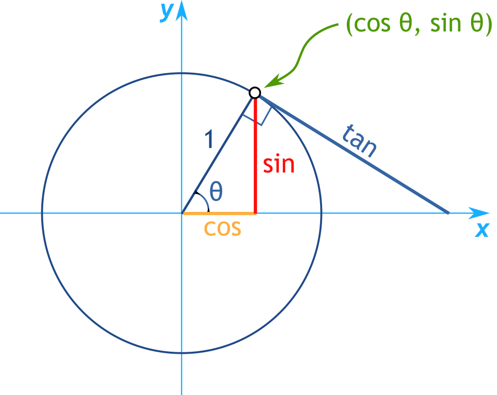

It follows from this that $\cos^2(\theta) + \sin^2(\theta) = 1$

## Graph of Sine and Cosine

As $-\infty < t < \infty$, $\sin(t)$ and $\cos(t)$ trace out the graph of a function:

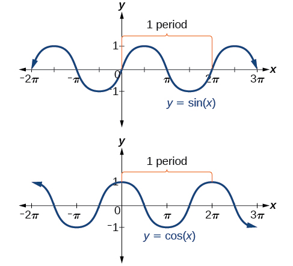

These functions are periodic with period $2\pi$.

## Periodic Functions

$\sin(t)$ and $\cos(t)$ (and combinations of them) can be used to model any periodic phenomenon using stretches and shifts of functions, e.g., $\cos(t) = \sin(t + \frac{\pi}{2})$.

$$f(x) = A\sin(Bt + C) + D$$

- Amplitude: $A$
- Period: $P = \dfrac{2\pi}{B} \Longleftrightarrow B = \dfrac{2\pi}{P}$
- Phase Shift: $C$
- Shift: $D$

## Example: Constructing Periodic Functions

**Example:** In a port city, high tide is at $9.9$ feet, and low tide is $0.1$ feet. High tide is at midnight and low tide is at noon. Find a formula for the height of the tide as a function of hours since midnight.

## Other Trigonometric Functions

Other well-known trigonometric functions can be defined in terms of $\sin(x)$ and $\cos(x)$:

- Tangent: $\tan(x) = \dfrac{\sin(x)}{\cos(x)}$
- Secant: $\sec(x) = \dfrac{1}{\cos(x)}$
- Cosecant: $\csc(x) = \dfrac{1}{\sin(x)}$
- Cotangent: $\cot(x) = \dfrac{\cos(x)}{\sin(x)}$

## Derivatives of Trigonometric Functions

$$\begin{aligned}
\frac{d}{dx} \sin(x) &= \cos(x) & &\textrm{and} & \frac{d}{dx} \cos(x) &= -\sin(x)
\end{aligned}$$

## Derivatives of Trigonometric Functions

Why? Use the definition of the derivative, the angle sum formula ($\sin(x + h) = \sin(x)\cos(h) + \cos(x)\sin(h)$) and some facts about limits:
$$\begin{aligned}
\frac{d}{dx} \sin(x) &= \lim\limits_{h \to 0} \frac{\sin(x+h) - \sin(x)}{h} \\
&= \lim\limits_{h \to 0} \frac{\sin(x)\cos(h) + \cos(x)\sin(h) - \sin(x)}{h} \\
&= \sin(x) \left( \lim\limits_{h \to 0} \frac{\cos(h) - 1}{h} \right) + \cos(x) \left( \lim\limits_{h \to 0} \frac{\sin(h)}{h} \right) \\
&= \sin(x) (0) + \cos(x) (1) \\
&= \cos(x)
\end{aligned}$$

## Examples: Derivatives of Trigonometric Functions

**Examples:**

1. Find $\dfrac{d}{dx} \tan(x)$.
2. Find $\dfrac{d}{dx} \sec(x)$.
3. Find $\dfrac{d}{dx} \csc(x)$.
4. Find $\dfrac{d}{dx} \cot(x)$.

## Examples: Derivatives of Trigonometric Functions

**Examples:**

1. Find $\dfrac{d}{dx} \sin^2(x)$.
2. Find $\dfrac{d}{dx} \cos(x^3 + x)$.
3. Find $\dfrac{d}{dx} \sqrt{x} \sin(3x^2 + 2)$.